# Predict survival on the Titanic

# 5. 모델 성능 개선

```r
titanic_data<-adata[,c("PassengerId","Survived","Pclass","Sex","Embarked","nametitle","age2","familysize","ticket_num" )]
str(titanic_data)
```

```
'data.frame':   1309 obs. of  9 variables:
 $ PassengerId: int  1 2 3 4 5 6 7 8 9 10 ...
 $ Survived   : Factor w/ 2 levels "0","1": 1 2 2 2 1 1 1 1 2 2 ...
 $ Pclass     : Ord.factor w/ 3 levels "1"<"2"<"3": 3 1 3 1 3 3 1 3 3 2 ...
 $ Sex        : Factor w/ 2 levels "female","male": 2 1 1 1 2 2 2 2 1 1 ...
 $ Embarked   : Factor w/ 3 levels "C","Q","S": 3 1 3 3 3 2 3 3 3 1 ...
 $ nametitle  : Factor w/ 6 levels "Honor","Master",..: 5 6 4 6 5 5 5 2 6 6 ...
 $ age2       : num  22 38 26 35 35 29 54 2 27 14 ...
 $ familysize : Factor w/ 3 levels "N","S","L": 2 2 1 2 1 1 1 3 2 2 ...
 $ ticket_num : Factor w/ 3 levels "N","S","L": 1 2 1 2 1 1 2 3 2 2 ...
```

```r
train_data<-titanic_data[!is.na(titanic_data$Survived),-1]
test_data<-titanic_data[is.na(titanic_data$Survived),-1]
str(train_data)
```

```
'data.frame':   891 obs. of  8 variables:
 $ Survived  : Factor w/ 2 levels "0","1": 1 2 2 2 1 1 1 1 2 2 ...
 $ Pclass    : Ord.factor w/ 3 levels "1"<"2"<"3": 3 1 3 1 3 3 1 3 3 2 ...
 $ Sex       : Factor w/ 2 levels "female","male": 2 1 1 1 2 2 2 2 1 1 ...
 $ Embarked  : Factor w/ 3 levels "C","Q","S": 3 1 3 3 3 2 3 3 3 1 ...
 $ nametitle : Factor w/ 6 levels "Honor","Master",..: 5 6 4 6 5 5 5 2 6 6 ...
 $ age2      : num  22 38 26 35 35 29 54 2 27 14 ...
 $ familysize: Factor w/ 3 levels "N","S","L": 2 2 1 2 1 1 1 3 2 2 ...
 $ ticket_num: Factor w/ 3 levels "N","S","L": 1 2 1 2 1 1 2 3 2 2 ...
```

```r
str(test_data)
```

```
'data.frame':   418 obs. of  8 variables:
 $ Survived  : Factor w/ 2 levels "0","1": NA NA NA NA NA NA NA NA NA NA ...
 $ Pclass    : Ord.factor w/ 3 levels "1"<"2"<"3": 3 3 2 3 3 3 3 2 3 3 ...
 $ Sex       : Factor w/ 2 levels "female","male": 2 1 2 2 1 2 1 2 1 2 ...
 $ Embarked  : Factor w/ 3 levels "C","Q","S": 2 3 2 3 3 3 2 3 1 3 ...
 $ nametitle : Factor w/ 6 levels "Honor","Master",..: 5 6 5 5 6 5 4 5 6 5 ...
 $ age2      : num  34.5 47 62 27 22 14 30 26 18 21 ...
 $ familysize: Factor w/ 3 levels "N","S","L": 1 2 1 1 2 1 1 2 1 2 ...
 $ ticket_num: Factor w/ 3 levels "N","S","L": 1 1 1 1 2 1 1 2 1 2 ...
```

```r
set.seed(1000)
model <- randomForest(train_data[,-1],train_data[,1], ntree=100, importance = T, mtry = 2, nodesize=10)
model
```

```
Call:
 randomForest(x = train_data[, -1], y = train_data[, 1], ntree = 100,      mtry = 2, nodesize = 10, importance = T)
               Type of random forest: classification
                     Number of trees: 100
No. of variables tried at each split: 2

        OOB estimate of  error rate: 16.95%
Confusion matrix:
    0   1 class.error
0 501  48  0.08743169
1 103 239  0.30116959
```

```r
importance(model)
```

```
                    0         1 MeanDecreaseAccuracy MeanDecreaseGini
Pclass     11.3730652 13.030719            16.279393        35.771324
Sex        11.5602287  8.813498            12.955551        54.190738
Embarked   -0.4865605  6.587542             4.986773         8.580115
nametitle  10.5134163 10.149213            12.398436        72.572755
age2        3.5390061  6.161441             6.815136        30.058665
familysize  5.5083589  6.397899             9.518895        15.979762
ticket_num  7.1886149  6.712276            10.958855        23.784935
```

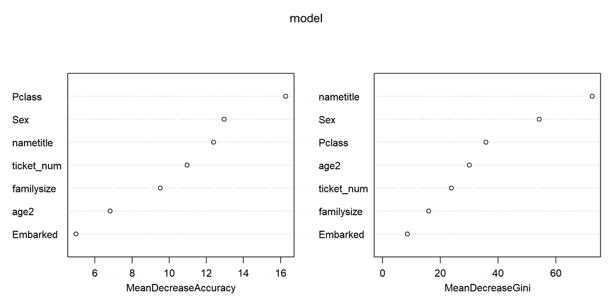

```r
varImpPlot(model)
```

```r
train_predict <- predict(model, train_data[,-1])
c<-CrossTable(train_predict, train_data[,1])
```

```
   Cell Contents
|-------------------------|
|                       N |
| Chi-square contribution |
|           N / Row Total |
|           N / Col Total |
|         N / Table Total |
|-------------------------|


Total Observations in Table:  891


              | train_data[, 1]
train_predict |         0 |         1 | Row Total |
--------------|-----------|-----------|-----------|
            0 |       507 |        94 |       601 |
              |    50.453 |    80.990 |           |
              |     0.844 |     0.156 |     0.675 |
              |     0.923 |     0.275 |           |
              |     0.569 |     0.105 |           |
--------------|-----------|-----------|-----------|
            1 |        42 |       248 |       290 |
              |   104.559 |   167.845 |           |
              |     0.145 |     0.855 |     0.325 |
              |     0.077 |     0.725 |           |
              |     0.047 |     0.278 |           |
--------------|-----------|-----------|-----------|
 Column Total |       549 |       342 |       891 |
              |     0.616 |     0.384 |           |
--------------|-----------|-----------|-----------|
```

```r
sum(diag(c$prop.tbl))
```

```
[1] 0.8473625
```

```r
predict3 <- predict(model, test_data[,-1], type="response")
table(predict3)
```

```
predict3
  0   1
270 148
```

```r
rf_result6_3<-data.frame(PassengerId = titanic_data[is.na(titanic_data$Survived),1],
                       Survived = predict3)

# write.csv(rf_result6_3,"D:\\data\\titanic\\result6f", row.names = FALSE) # 제출 결과 0.80382
```

오버피팅을 개선하기 위해 우선 분석 컬럼을 조절했습니다. 연속형이며 오른쪽으로 꼬리가 긴 분포를 가진 Fare 컬럼은 제거했습니다.  
ntree=100, mtry = 2, nodesize=10  
Tree 수를 100개로 낮추고, mtry=2와 nodesize = 10를 지정했습니다. train data 정확도가 0.84로 감소했으며 제출결과 점수도 오른것을 확인 했습니다.

# 6. 결론과 한계

파생변수를 잘못 생성한 경우 오버피팅되고 잘못된 예측을 하는 경우가 발생했습니다. 최적의 모델은 중요도가 높은 적당한 변수를 사용 했을 때 나타났습니다.  
train data를 잘 예측해도 test data는 잘 예측하지 못하는 경우가 많았습니다. 오버피팅 문제를 개선하기 위한 방법을 찾아야 합니다.  
최종 모델은 kaggle 제출 결과 상위 6% 결과이며 더 좋은 모델을 찾기 위한 다른 모델과 부스팅 기법의 연구가 필요합니다.

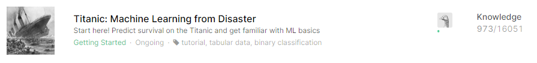

kaggle_leaderboard